# Clinical Performance of Tumor-Informed versus Tumor-Agnostic ctDNA Assays for Colorectal Cancer Recurrence

- Show All Code
- Hide All Code
- View Source

A Systematic Review and Diagnostic Accuracy Meta-Analysis

Authors

[Daniel G. Camblor*](https://github.com/dgcamblor)

Belén Martínez-Castedo

Jorge Martín-Arana

Francisco Gimeno-Valiente

Blanca García-Micó

Francisco Martínez-Picó

Víctor Seguí

Miguel García-Bartolomé

Diego González

Alejandro Guimera

Marisol Huerta

Susana Roselló

Valentina Gambardella

Desamparados Roda

Leon Pappas

Aparna Parikh

Juan A. Carbonell-Asins*

Andrés Cervantes

Noelia Tarazona

* Main developers of the code.

# 1 QUADAS-2

QUADAS-2 is a tool for assessing the risk of bias and applicability of diagnostic accuracy studies. Here, we present the results of our QUADAS-2 assessment for the included studies.

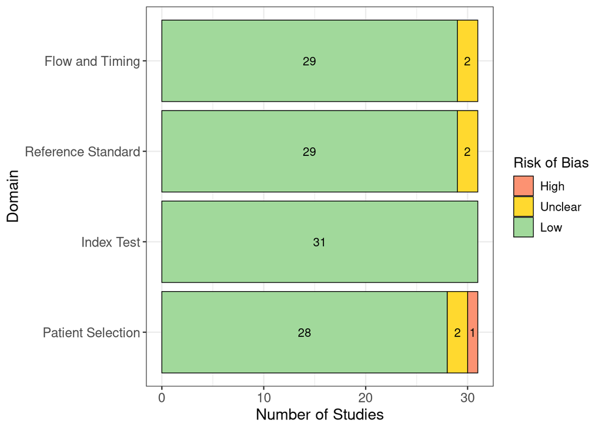

```r
quadas %>%
  mutate(Score = factor(Score, levels = c("High", "Unclear", "Low"))) %>%
  count(Domain, Score) %>%
  ggplot(aes(x = n, y = Domain, fill = Score)) +
  geom_bar(stat = "identity", color = "black", linewidth = 0.3) +
  geom_text(aes(label = n),
            position = position_stack(vjust = 0.5),
            size = 3.5, color = "black") +
  scale_fill_manual(
    values = c(
      "Low"     = "#A1D99B",
      "Unclear" = "#FFD92F",
      "High"    = "#FC9272"
    )
  ) +
  labs(
    x = "Number of Studies",
    y = "Domain",
    fill = "Risk of Bias"
  ) +
  theme(
    axis.title = element_text(size = 13),
    axis.text = element_text(size = 11),
    legend.title = element_text(size = 12),
    legend.text = element_text(size = 10)
  )
```

```r
ggsave("results/plots/quadas2.png", width = 8, height = 5, dpi = 300)
```

# 2 Number of studies

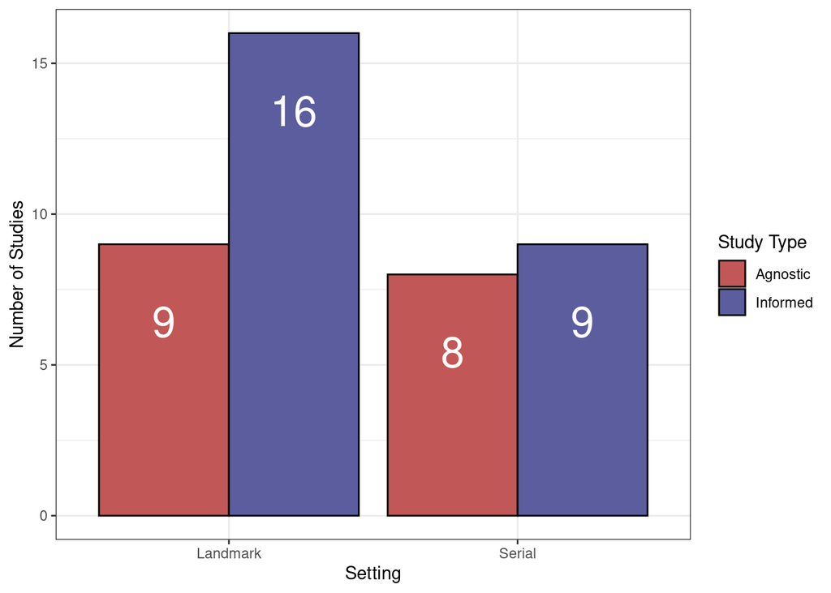

```r
data %>%
  count(SETTING, APPROACH) %>%
  ggplot(aes(x = SETTING, y = n, fill = APPROACH)) +
  geom_bar(stat = "identity", position = "dodge", color = "black") +
  geom_text(aes(label = n), vjust = 3, position = position_dodge(0.9), color = "white", size = 9) +
  scale_fill_manual(values = colors) +
  labs(x = "Setting", y = "Number of Studies", fill = "Study Type")
```

There are 42 study results included in the meta-analysis (corresponding to 31 studies; one study can provide results for both the landmark and serial settings), with 25 study results in the landmark setting and 17 study results in the serial setting. The majority of studies are tumor-informed.

# 3 Descriptive analysis: univariate (DOR) approach

As an initial exploratory analysis, we can use the diagnostic odds ratio (DOR) as a univariate measure of diagnostic accuracy. The DOR is a single summary measure that combines sensitivity and specificity into a single number, which is useful for certain analyses although not ideal for meta-regression, as explained throughout this document.

The diagnostic odds ratio (DOR) can be expressed as:

$$\text{DOR} = \frac{\text{TP} \times \text{TN}}{\text{FP} \times \text{FN}}$$

## 3.1 Deeks’ test and funnel plot

The first step of the meta-analysis is to check for publication bias. In the context of diagnostic accuracy studies, this is done using Deeks’ test. This test is based on the idea that if there is no publication bias, the log odds ratio (logOR) should be symmetrically distributed in relation to the Effective Sample Size (ESS).

The ESS quantifies the amount of independent information contained in a sample, especially when the data are correlated. In the context of diagnostic accuracy studies, the ESS can be calculated as:

$$\text{ESS} = \frac{TP \times TN}{TP + TN + FP + FN}$$

The results from the univariate analysis (based on the DOR) are summarized in the following sections, including the Deeks’ test.

### 3.1.1 Landmark setting

```r
m_landmark <- metabin(
  data_landmark$TP,
  data_landmark$TP + data_landmark$FP,
  data_landmark$FN,
  data_landmark$FN + data_landmark$TN,
  data = data_landmark,
  sm = "DOR"
)

m_landmark_sg <- metabin(
  data_landmark$TP,
  data_landmark$TP + data_landmark$FP,
  data_landmark$FN,
  data_landmark$FN + data_landmark$TN,
  data = data_landmark,
  subgroup = data_landmark$APPROACH,
  sm = "DOR"
)
```

```r
summary(m_landmark_sg)
```

```
        DOR               95%-CI %W(common) %W(random) APPROACH
1    5.0286 [ 1.7819;   14.1911]        4.6        4.5 Agnostic
2   13.3333 [ 1.6549;  107.4266]        0.8        1.8 Informed
3   15.0000 [ 5.4864;   41.0104]        2.5        4.7 Informed
4   10.0882 [ 2.9176;   34.8824]        3.0        3.7 Informed
5   11.1222 [ 3.6496;   33.8952]        3.0        4.2 Informed
6    3.7500 [ 0.4954;   28.3889]        1.7        1.9 Informed
7   16.4667 [ 4.7178;   57.4744]        2.1        3.7 Informed
8   17.8182 [ 5.4248;   58.5247]        2.4        3.9 Informed
9   24.9885 [13.1008;   47.6631]        5.3        6.5 Informed
10   5.2556 [ 1.7185;   16.0725]        4.6        4.2 Agnostic
11 440.0000 [25.7798; 7509.7454]        0.1        1.1 Agnostic
12  32.7955 [14.5493;   73.9241]        3.2        5.6 Agnostic
13  18.3600 [ 7.5999;   44.3546]        2.9        5.2 Agnostic
14  25.8377 [19.2700;   34.6437]       28.4        8.2 Informed
15  11.3929 [ 3.2913;   39.4365]        3.0        3.7 Agnostic
16  25.6250 [ 5.1244;  128.1390]        1.3        2.7 Agnostic
17  17.2667 [ 3.8331;   77.7794]        1.2        2.9 Informed
18  17.2500 [ 5.3765;   55.3449]        2.1        4.0 Informed
19  10.3333 [ 2.9568;   36.1130]        2.0        3.7 Agnostic
20   6.8148 [ 1.9004;   24.4373]        2.9        3.6 Informed
21  33.9167 [ 8.5595;  134.3934]        1.0        3.3 Informed
22   4.4286 [ 1.5481;   12.6682]        5.5        4.5 Informed
23   3.1081 [ 1.2424;    7.7754]        7.6        5.1 Informed
24  52.2414 [ 2.8129;  970.2336]        0.4        1.0 Informed
25   7.3684 [ 3.6373;   14.9269]        8.2        6.1 Agnostic

Number of studies: k = 25
Number of observations: o = 6131 (o.e = 923, o.c = 5208)
Number of events: e = 1199

                         DOR             95%-CI     z  p-value
Common effect model  16.3518 [13.7345; 19.4679] 31.40 < 0.0001
Random effects model 13.0743 [ 9.5284; 17.9399] 15.93 < 0.0001

Quantifying heterogeneity (with 95%-CIs):
 tau^2 = 0.2953 [0.0741; 1.0468]; tau = 0.5434 [0.2721; 1.0231]
 I^2 = 59.5% [37.1%; 73.9%]; H = 1.57 [1.26; 1.96]

Test of heterogeneity:
```

[output cut: 13 more lines]

```
                      k     DOR            95%-CI  tau^2    tau
APPROACH = Agnostic   9 13.0253 [7.4817; 22.6767] 0.3709 0.6091
APPROACH = Informed  16 13.1723 [8.8306; 19.6487] 0.2999 0.5476

Test for subgroup differences (random effects model):
                  Q d.f. p-value
Between groups 0.00    1  0.9743

Details of meta-analysis methods:
- Mantel-Haenszel method (common effect model)
- Inverse variance method (random effects model)
- Restricted maximum-likelihood estimator for tau^2
- Q-Profile method for confidence interval of tau^2 and tau
- Calculation of I^2 based on Q
- Continuity correction of 0.5 in studies with zero cell frequencies
```

The heterogeneity is moderate, which is expected given the different study designs and populations included.

```r
m_landmark_bias <- metabias(m_landmark, method.bias = "Deeks"); m_landmark_bias
```

```
Funnel plot test for diagnostic odds ratios

Test result: t = -1.42, df = 23, p-value = 0.1686
Bias estimate: -4.7250 (SE = 3.3238)

Details:
- multiplicative residual heterogeneity variance (tau^2 = 73.5929)
- predictor: inverse of the squared effective sample size
- weight:    effective sample size
- reference: Deeks et al. (2005), J Clin Epid
```

A p-value > 0.05 indicates that there is no evidence of publication bias.

### 3.1.2 Serial setting

```r
m_serial <- metabin(
  data_serial$TP,
  data_serial$TP + data_serial$FP,
  data_serial$FN,
  data_serial$FN + data_serial$TN,
  data = data_serial,
  sm = "DOR"
)

m_serial_sg <- metabin(
  data_serial$TP,
  data_serial$TP + data_serial$FP,
  data_serial$FN,
  data_serial$FN + data_serial$TN,
  data = data_serial,
  subgroup = data_serial$APPROACH,
  sm = "DOR"
)
```

```r
summary(m_serial_sg)
```

```
        DOR                95%-CI %W(common) %W(random) APPROACH
1   62.1111 [ 2.9397;  1312.3021]        0.3        3.7 Informed
2   76.0000 [19.5551;   295.3712]        0.9        6.9 Informed
3   27.3913 [ 5.9314;   126.4937]        1.9        6.5 Informed
4  623.0000 [61.6803;  6292.5913]        0.1        4.9 Informed
5   18.0000 [ 1.4957;   216.6201]        0.7        4.6 Agnostic
6   27.4490 [12.6538;    59.5429]        3.9        8.0 Agnostic
7   42.5000 [10.9401;   165.1038]        1.5        6.9 Agnostic
8   45.5556 [ 8.9906;   230.8308]        1.1        6.3 Agnostic
9    3.7125 [ 1.3591;    10.1413]        7.6        7.6 Agnostic
10 143.0000 [ 2.4151;  8467.0059]        0.1        2.6 Informed
11 406.0000 [34.3282;  4801.7697]        0.1        4.7 Informed
12 725.0000 [13.3821; 39278.1701]        0.0        2.7 Informed
13   9.9904 [ 4.0892;    24.4077]        5.7        7.8 Agnostic
14   2.2036 [ 1.4808;     3.2794]       63.9        8.5 Agnostic
15  35.7778 [ 7.9075;   161.8775]        1.2        6.5 Informed
16 273.0000 [13.0822;  5696.9606]        0.1        3.8 Informed
17  10.4942 [ 5.3827;    20.4596]       10.9        8.1 Agnostic

Number of studies: k = 17
Number of observations: o = 2865 (o.e = 590, o.c = 2275)
Number of events: e = 561

                         DOR             95%-CI     z  p-value
Common effect model   9.5138 [ 7.6674; 11.8049] 20.46 < 0.0001
Random effects model 31.4135 [14.3329; 68.8490]  8.61 < 0.0001

Quantifying heterogeneity (with 95%-CIs):
 tau^2 = 1.8542 [0.6926; 5.3405]; tau = 1.3617 [0.8322; 2.3109]
 I^2 = 86.4% [79.7%; 90.9%]; H = 2.71 [2.22; 3.31]

Test of heterogeneity:
      Q d.f.  p-value
 117.69   16 < 0.0001

Results for subgroups (common effect model):
                      k     DOR              95%-CI     Q   I^2
APPROACH = Informed   9 79.6700 [39.6167; 160.2180]  9.56 16.3%
APPROACH = Agnostic   8  6.0253 [ 4.7084;   7.7106] 58.72 88.1%

Test for subgroup differences (common effect model):
                   Q d.f.  p-value
Between groups 46.65    1 < 0.0001

Results for subgroups (random effects model):
                      k     DOR              95%-CI  tau^2    tau
APPROACH = Informed   9 96.5906 [41.1665; 226.6345] 0.4135 0.6430
APPROACH = Agnostic   8 11.4316 [ 5.0729;  25.7607] 1.0378 1.0187

Test for subgroup differences (random effects model):
                   Q d.f. p-value
Between groups 12.61    1  0.0004

Details of meta-analysis methods:
- Mantel-Haenszel method (common effect model)
- Inverse variance method (random effects model)
- Restricted maximum-likelihood estimator for tau^2
- Q-Profile method for confidence interval of tau^2 and tau
- Calculation of I^2 based on Q
- Continuity correction of 0.5 in studies with zero cell frequencies
```

When evaluating the serial setting, the heterogeneity is lower in tumor-informed studies but increases dramatically in the agnostic studies. This is likely due to the fact that the agnostic studies are more heterogeneous in terms of the methodologies used (genomics, methylomics, and integrated approaches).

```r
m_serial_bias <- metabias(m_serial, method.bias = "Deeks"); m_serial_bias
```

```
Funnel plot test for diagnostic odds ratios

Test result: t = 4.10, df = 15, p-value = 0.0009
Bias estimate: 26.7834 (SE = 6.5342)

Details:
- multiplicative residual heterogeneity variance (tau^2 = 151.6305)
- predictor: inverse of the squared effective sample size
- weight:    effective sample size
- reference: Deeks et al. (2005), J Clin Epid
```

Here, the p-value is < 0.05, suggesting that there is evidence of publication bias. In summary, the Deeks’ test estimate is the slope coefficient from the regression of log DOR on 1/√ESS. Here, a positive estimate indicates that studies with smaller sample sizes (lower ESS) have larger log DORs.

### 3.1.3 Deeks’ funnel plot

```r
# We generate the funnel plot and extract the data to re-create it with ggplot
pfunnel_landmark <- funnel(m_landmark_sg, yaxis = "ess", studlab = data_landmark$STUDY)
```

```r
pfunnel_lab_landmark <- paste0(
  "Deeks' test p = ", signif(m_landmark_bias$p.value, 3), "; ",
  "bias estimate = ", signif(m_landmark_bias$estimate[1], 3)
)

pfunnel_landmark <- data.frame(
  x = pfunnel_landmark$xvals,
  y = pfunnel_landmark$yvals,
  study = data_landmark$STUDY,
  approach = data_landmark$APPROACH,
  size = data_landmark$N
  ) %>%
  ggplot(aes(x = log(x), y = y, text = study, group = approach, color = approach)) +
  geom_line(stat="smooth", method = "lm", size = 0.8, alpha = 0.5) +
  geom_point(aes(size = size)) +
  # geom_text_repel(aes(label = study), size = 3, max.overlaps = 20) +
  scale_color_manual(values = colors) +
  scale_y_reverse() +
  labs(
    title = "Landmark setting",
    subtitle = pfunnel_lab_landmark,
    x = "Log(Diagnostic Odds Ratio)",
    y = "1 / sqrt(ESS)"
  )
```

```r
pfunnel_serial <- funnel(m_serial, yaxis = "ess", studlab = data_serial$STUDY)
```

```r
pfunnel_lab_serial <- paste0(
  "Deeks' test p = ", signif(m_serial_bias$p.value, 3), "; ",
  "bias estimate = ", signif(m_serial_bias$estimate[1], 3)
)

pfunnel_serial <- data.frame(
  x = pfunnel_serial$xvals,
  y = pfunnel_serial$yvals,
  study = data_serial$STUDY,
  approach = data_serial$APPROACH,
  size = data_serial$N
  ) %>%
  ggplot(aes(x = log(x), y = y, text = study, group = approach, color = approach)) +
  geom_line(stat="smooth", method = "lm", size = 0.8, alpha = 0.5) +
  geom_point(aes(size = size)) +
  # geom_text_repel(aes(label = study), size = 3, max.overlaps = 20) +
  labs(x = "Log(Diagnostic Odds Ratio)", y = "1 / sqrt(ESS)") +
  scale_color_manual(values = colors) +
  scale_y_reverse() +
  labs(
    title = "Serial setting",
    subtitle = pfunnel_lab_serial,
    x = " ",
    y = ""
  )
```

```r
png("results/plots/pfunnel_landmark_serial.png", width = 1200, height = 600, res = 140)
cowplot::plot_grid(
  pfunnel_landmark + theme(legend.position = "none"),
  pfunnel_serial,
  ncol = 2,
  labels = c("A", "B"),
  label_size = 12,
  rel_widths = c(0.8, 1)
)
dev.off()
```

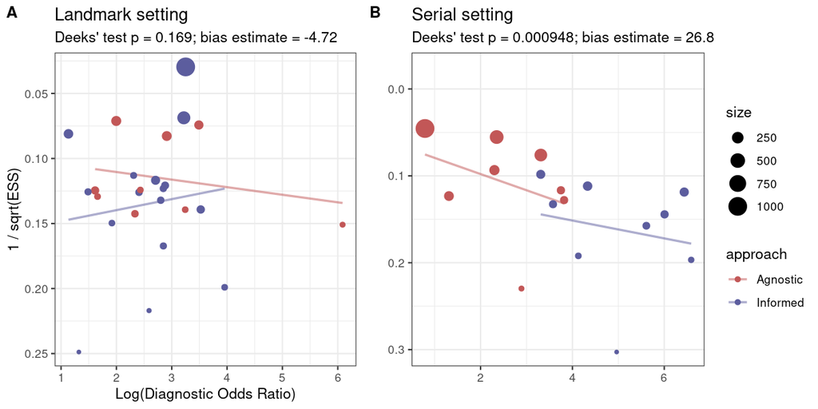

```r
knitr::include_graphics("results/plots/pfunnel_landmark_serial.png")
```

## 3.2 Forest plot

### 3.2.1 Landmark setting

```r
madad_landmark <- madad(data_landmark %>% mutate(names = STUDY))
```

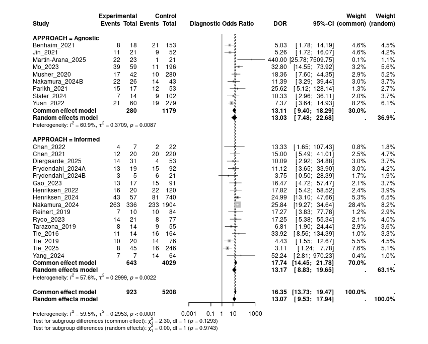

```r
meta::forest(
  m_landmark_sg,
  studlab = data_landmark$STUDY,
  col.diamond = "black",
  file = "results/plots/pforest_landmark.png",
  width = 850
  )

knitr::include_graphics("results/plots/pforest_landmark.png")
```

### 3.2.2 Serial setting

```r
madad_serial <- madad(data_serial %>% mutate(names = STUDY))
```

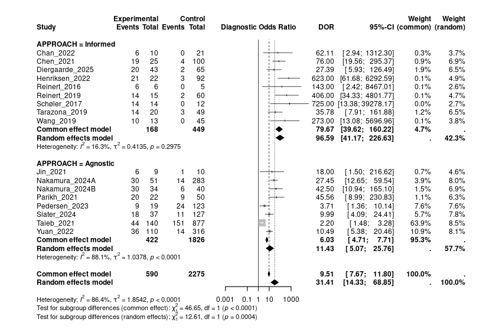

```r
meta::forest(
  m_serial_sg,
  studlab = data_serial$STUDY,
  col.diamond = "black",
  file = "results/plots/pforest_serial.png",
  width = 850
  )

knitr::include_graphics("results/plots/pforest_serial.png")
```

# 4 Bivariate Meta-Analysis

As stated before, bivariate meta-analysis according to the Reitsma model combines the sensivitiy and specificity. The model assumes that the true positive rate (TPR) and false positive rate (FPR) are correlated.

## 4.1 Landmark vs. Serial

We can perform a initial bivariate meta-analysis comparison of the landmark and serial data. It is expected that the serial analysis of ctDNA yields a more accurate assessment of the risk of recurrence than the landmark analysis.

```r
fit_landmark <- reitsma(data_landmark)
fit_serial <- reitsma(data_serial)
```

```r
png("results/plots/sroc_global.png", width = 550, height = 550, res = 120)

# Extract the data for the Landmark and Serial SROC curves
landmark_sroc <- sroc(fit_landmark)
serial_sroc <- sroc(fit_serial)

# Start with a blank plot for the SROC curves
plot(
  landmark_sroc,
  xlim = c(0, 0.3),
  ylim = c(0, 1),
  main = "Landmark vs. Serial",
  xlab = "False Positive Rate",
  ylab = "Sensitivity",
  type = "n"  # 'type = "n"' makes a blank plot
  )

# Add the SROC curves
lines(landmark_sroc, col = "#3E6D9C", lwd = 2)
lines(serial_sroc, col = "#FD841F", lwd = 2)

# Add confidence ellipses
ROCellipse(fit_landmark, pch = 1, col = "#3E6D9C", add = TRUE)  # Landmark ellipses
ROCellipse(fit_serial, pch = 2, col = "#FD841F", add = TRUE)  # Serial ellipses

# Add points
points(fpr(data_landmark), sens(data_landmark), col = "#3E6D9C", cex = 0.5)
points(fpr(data_serial), sens(data_serial), col = "#FD841F", pch = 2, cex = 0.5)

# Add a legend
legend("bottomright", legend = c("Landmark", "Serial"), col = c("#3E6D9C", "#FD841F"), pch = 1:2, lty = 1:2)

dev.off()
```

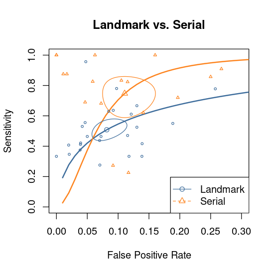

```r
knitr::include_graphics("results/plots/sroc_global.png")
```

```r
fit_all <- reitsma(data, formula = cbind(tsens, tfpr) ~ SETTING)
summary(fit_all)
```

```
Call:  reitsma.default(data = data, formula = cbind(tsens, tfpr) ~ SETTING)

Bivariate diagnostic random-effects meta-analysis
Estimation method: REML

Fixed-effects coefficients
                    Estimate Std. Error       z Pr(>|z|) 95%ci.lb 95%ci.ub
tsens.(Intercept)      0.030      0.167   0.182    0.856   -0.297    0.358
tsens.SETTINGSerial    0.922      0.284   3.249    0.001    0.366    1.479  **
tfpr.(Intercept)      -2.413      0.146 -16.578    0.000   -2.698   -2.128 ***
tfpr.SETTINGSerial     0.354      0.236   1.497    0.134   -0.109    0.817
---
Signif. codes:  0 '***' 0.001 '**' 0.01 '*' 0.05 '.' 0.1 ' ' 1

Variance components: between-studies Std. Dev and correlation matrix
      Std. Dev tsens  tfpr
tsens    0.719 1.000     .
tfpr     0.598 0.263 1.000

  logLik      AIC      BIC
  78.366 -142.732 -125.716


I2 estimates
Zhou and Dendukuri approach:  21.8 %
Holling sample size unadjusted approaches:  45.5 - 82.1 %
Holling sample size adjusted approaches:  4.2 - 5.8 %
```

To have a clearer picture of the results, we can transform logit estimates into percentages.

- The intercept represents the base value of the reference category.
- The logit estimate below corresponds to the (logit) difference

```r
summary(fit_all)$coefficients %>%
  as.data.frame() %>%
  rownames_to_column("Var") %>%
  select(Var, Estimate, `95%ci.lb`, `95%ci.ub`) %>%
  mutate(
    Measure = case_when(
      str_detect(Var, "^tsens") ~ "Sensitivity",
      str_detect(Var, "^tfpr") ~ "False Positive Rate",
      TRUE ~ NA_character_
    ),
    Type = case_when(
      str_detect(Var, "Intercept") ~ "Intercept",
      str_detect(Var, "Serial") ~ "Effect",
      TRUE ~ NA_character_
    )
  ) %>%
  # Spread intercepts to join with effects
  group_by(Measure) %>%
  mutate(
    Intercept_Estimate = Estimate[Type == "Intercept"],
    Intercept_LB = `95%ci.lb`[Type == "Intercept"],
    Intercept_UB = `95%ci.ub`[Type == "Intercept"]
  ) %>%
  ungroup() %>%
  # Calculate combined logit for effects, or keep intercept
  mutate(
    Logit = if_else(Type == "Effect", Estimate + Intercept_Estimate, Estimate),
    Logit_LB = if_else(Type == "Effect", `95%ci.lb` + Intercept_LB, `95%ci.lb`),
    Logit_UB = if_else(Type == "Effect", `95%ci.ub` + Intercept_UB, `95%ci.ub`),
    Probability = plogis(Logit),
    Probability_LB = plogis(Logit_LB),
    Probability_UB = plogis(Logit_UB)
  ) %>%
  select(Measure, Type, Probability, Probability_LB, Probability_UB) %>%
  mutate(
    Type = case_when(
      Type == "Intercept" ~ "Landmark",
      Type == "Effect" ~ "Serial"
    )
  ) %>%
  knitr::kable()
```

| Measure | Type | Probability | Probability_LB | Probability_UB |
| --- | --- | --- | --- | --- |
| Sensitivity | Landmark | 0.5075807 | 0.4262725 | 0.5884899 |
| Sensitivity | Serial | 0.7216264 | 0.5171978 | 0.8625068 |
| False Positive Rate | Landmark | 0.0821820 | 0.0630708 | 0.1064262 |
| False Positive Rate | Serial | 0.1131330 | 0.0569028 | 0.2124137 |

Using a serial approach significantly increases the sensitivity of recurrence detection compared to a landmark approach. The true-false positive rate raises slightly, but the increase is non-significant.

## 4.2 Tumor-Informed vs. Tumor-Agnostic

```r
data_landmark_inf <- data_landmark %>% filter(APPROACH == "Informed")
data_landmark_agn <- data_landmark %>% filter(APPROACH == "Agnostic")

data_serial_inf <- data_serial %>% filter(APPROACH == "Informed")
data_serial_agn <- data_serial %>% filter(APPROACH == "Agnostic")
```

#### 4.2.0.1 Landmark setting

```r
fit_landmark_inf <- reitsma(data_landmark_inf)
fit_landmark_agn <- reitsma(data_landmark_agn)
```

##### 4.2.0.1.1 SROC curves

```r
png("results/plots/sroc_landmark.png", width = 550, height = 550, res = 120)

# Extract the data for the Informed and Agnostic SROC curves
landmark_inf_sroc <- sroc(fit_landmark_inf)
landmark_agn_sroc <- sroc(fit_landmark_agn)

# Start with a blank plot for the SROC curves
plot(
  landmark_inf_sroc,
  xlim = c(0, 0.3),
  ylim = c(0, 1),
  main = "Landmark setting",
  xlab = "False Positive Rate",
  ylab = "Sensitivity",
  type = "n"
  )

# Add the SROC curves
lines(landmark_inf_sroc, col = colors["Informed"], lwd = 2)
lines(landmark_agn_sroc, col = colors["Agnostic"], lwd = 2)

# Add confidence ellipses
ROCellipse(fit_landmark_inf, pch = 1, col = colors["Informed"], add = TRUE)  # Landmark ellipses
ROCellipse(fit_landmark_agn, pch = 2, col = colors["Agnostic"], add = TRUE)  # Serial ellipses

# Add points
points(fpr(data_landmark_inf), sens(data_landmark_inf), col = colors["Informed"], cex = 0.5)
points(fpr(data_landmark_agn), sens(data_landmark_agn), col = colors["Agnostic"], pch = 2, cex = 0.5)

# Add a legend
legend("bottomright", legend = c("Informed", "Agnostic"), col = c(colors["Informed"], colors["Agnostic"]), pch = 1:2, lty = 1:2)

dev.off()
```

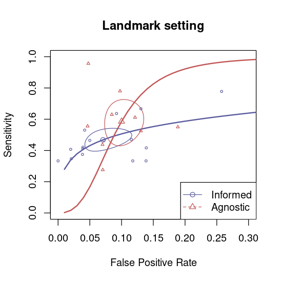

```r
knitr::include_graphics("results/plots/sroc_landmark.png")
```

##### 4.2.0.1.2 Bivariate modeling

```r
fit_landmark <- reitsma(data_landmark, formula = cbind(tsens, tfpr) ~ APPROACH)
summary(fit_landmark)
```

```
Call:  reitsma.default(data = data_landmark, formula = cbind(tsens,
    tfpr) ~ APPROACH)

Bivariate diagnostic random-effects meta-analysis
Estimation method: REML

Fixed-effects coefficients
                       Estimate Std. Error      z Pr(>|z|) 95%ci.lb 95%ci.ub
tsens.(Intercept)         0.325      0.188  1.727    0.084   -0.044    0.693
tsens.APPROACHInformed   -0.467      0.233 -2.006    0.045   -0.923   -0.011
tfpr.(Intercept)         -2.183      0.248 -8.796    0.000   -2.670   -1.697
tfpr.APPROACHInformed    -0.375      0.314 -1.198    0.231   -0.990    0.239

tsens.(Intercept)        .
tsens.APPROACHInformed   *
tfpr.(Intercept)       ***
tfpr.APPROACHInformed
---
Signif. codes:  0 '***' 0.001 '**' 0.01 '*' 0.05 '.' 0.1 ' ' 1

Variance components: between-studies Std. Dev and correlation matrix
      Std. Dev tsens  tfpr
tsens    0.387 1.000     .
tfpr     0.633 0.508 1.000

 logLik     AIC     BIC
 53.635 -93.269 -79.885


I2 estimates
Zhou and Dendukuri approach:  23.2 %
Holling sample size unadjusted approaches:  32.9 - 56.4 %
Holling sample size adjusted approaches:  1.5 - 1.7 %
```

```r
summary(fit_landmark)$coefficients %>%
  as.data.frame() %>%
  rownames_to_column("Var") %>%
  select(Var, Estimate, `95%ci.lb`, `95%ci.ub`) %>%
  mutate(
    Measure = case_when(
      str_detect(Var, "^tsens") ~ "Sensitivity",
      str_detect(Var, "^tfpr") ~ "False Positive Rate",
      TRUE ~ NA_character_
    ),
    Type = case_when(
      str_detect(Var, "Intercept") ~ "Intercept",
      str_detect(Var, "Informed") ~ "Effect",
      TRUE ~ NA_character_
    )
  ) %>%
  # Spread intercepts to join with effects
  group_by(Measure) %>%
  mutate(
    Intercept_Estimate = Estimate[Type == "Intercept"],
    Intercept_LB = `95%ci.lb`[Type == "Intercept"],
    Intercept_UB = `95%ci.ub`[Type == "Intercept"]
  ) %>%
  ungroup() %>%
  # Calculate combined logit for effects, or keep intercept
  mutate(
    Logit = if_else(Type == "Effect", Estimate + Intercept_Estimate, Estimate),
    Logit_LB = if_else(Type == "Effect", `95%ci.lb` + Intercept_LB, `95%ci.lb`),
    Logit_UB = if_else(Type == "Effect", `95%ci.ub` + Intercept_UB, `95%ci.ub`),
    Probability = plogis(Logit),
    Probability_LB = plogis(Logit_LB),
    Probability_UB = plogis(Logit_UB)
  ) %>%
  select(Measure, Type, Probability, Probability_LB, Probability_UB) %>%
  mutate(
    Type = case_when(
      Type == "Intercept" ~ "Agnostic",
      Type == "Effect" ~ "Informed"
    )
  ) %>%
  knitr::kable()
```

| Measure | Type | Probability | Probability_LB | Probability_UB |
| --- | --- | --- | --- | --- |
| Sensitivity | Agnostic | 0.5804469 | 0.4890733 | 0.6666185 |
| Sensitivity | Informed | 0.4644790 | 0.2754952 | 0.6642453 |
| False Positive Rate | Agnostic | 0.1012598 | 0.0647788 | 0.1548829 |
| False Positive Rate | Informed | 0.0718402 | 0.0250933 | 0.1888073 |

#### 4.2.0.2 Serial setting

```r
fit_serial_inf <- reitsma(data_serial_inf)
fit_serial_agn <- reitsma(data_serial_agn)
```

##### 4.2.0.2.1 SROC curves

```r
png("results/plots/sroc_serial.png", width = 550, height = 550, res = 120)

# Extract the data for the Informed and Agnostic SROC curves
serial_inf_sroc <- sroc(fit_serial_inf)
serial_agn_sroc <- sroc(fit_serial_agn)

# Start with a blank plot for the SROC curves
plot(
  serial_inf_sroc,
  xlim = c(0, 0.3),
  ylim = c(0, 1),
  main = "Serial setting",
  xlab = "False Positive Rate",
  ylab = "Sensitivity",
  type = "n"  # 'type = "n"' makes a blank plot
  )

# Add the SROC curves
lines(serial_inf_sroc, col = colors["Informed"], lwd = 2)
lines(serial_agn_sroc, col = colors["Agnostic"], lwd = 2)

# Add confidence ellipses
ROCellipse(fit_serial_inf, pch = 1, col = colors["Informed"], add = TRUE)
ROCellipse(fit_serial_agn, pch = 2, col = colors["Agnostic"], add = TRUE)

# Add points
points(fpr(data_serial_inf), sens(data_serial_inf), col = colors["Informed"], cex = 0.5)
points(fpr(data_serial_agn), sens(data_serial_agn), col = colors["Agnostic"], pch = 2, cex = 0.5)

# Add a legend
legend("bottomright", legend = c("Informed", "Agnostic"), col = c(colors["Informed"], colors["Agnostic"]), pch = 1:2, lty = 1:2)

dev.off()
```

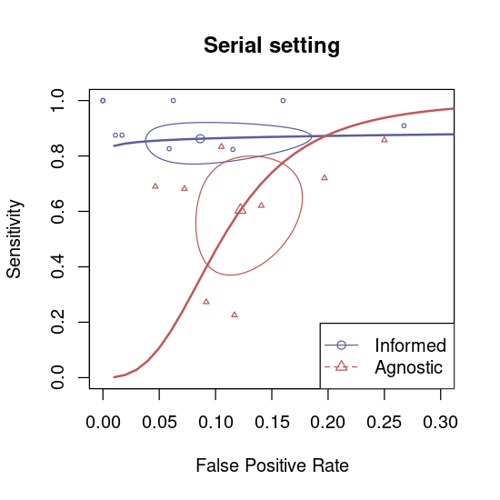

```r
knitr::include_graphics("results/plots/sroc_serial.png")
```

##### 4.2.0.2.2 Bivariate modeling

```r
fit_serial <- reitsma(data_serial, formula = cbind(tsens, tfpr) ~ APPROACH)
summary(fit_serial)
```

```
Call:  reitsma.default(data = data_serial, formula = cbind(tsens, tfpr) ~
    APPROACH)

Bivariate diagnostic random-effects meta-analysis
Estimation method: REML

Fixed-effects coefficients
                       Estimate Std. Error      z Pr(>|z|) 95%ci.lb 95%ci.ub
tsens.(Intercept)         0.373      0.311  1.199    0.231   -0.237    0.984
tsens.APPROACHInformed    1.598      0.499  3.202    0.001    0.620    2.576
tfpr.(Intercept)         -1.954      0.241 -8.090    0.000   -2.427   -1.480
tfpr.APPROACHInformed    -0.302      0.374 -0.808    0.419   -1.034    0.430

tsens.(Intercept)
tsens.APPROACHInformed  **
tfpr.(Intercept)       ***
tfpr.APPROACHInformed
---
Signif. codes:  0 '***' 0.001 '**' 0.01 '*' 0.05 '.' 0.1 ' ' 1

Variance components: between-studies Std. Dev and correlation matrix
      Std. Dev tsens  tfpr
tsens    0.781 1.000     .
tfpr     0.588 0.225 1.000

 logLik     AIC     BIC
 35.538 -57.076 -46.391


I2 estimates
Zhou and Dendukuri approach:  37.4 %
Holling sample size unadjusted approaches:  59.1 - 91.5 %
Holling sample size adjusted approaches:  9 - 12.8 %
```

```r
summary(fit_serial)$coefficients %>%
  as.data.frame() %>%
  rownames_to_column("Var") %>%
  select(Var, Estimate, `95%ci.lb`, `95%ci.ub`) %>%
  mutate(
    Measure = case_when(
      str_detect(Var, "^tsens") ~ "Sensitivity",
      str_detect(Var, "^tfpr") ~ "False Positive Rate",
      TRUE ~ NA_character_
    ),
    Type = case_when(
      str_detect(Var, "Intercept") ~ "Intercept",
      str_detect(Var, "Informed") ~ "Effect",
      TRUE ~ NA_character_
    )
  ) %>%
  # Spread intercepts to join with effects
  group_by(Measure) %>%
  mutate(
    Intercept_Estimate = Estimate[Type == "Intercept"],
    Intercept_LB = `95%ci.lb`[Type == "Intercept"],
    Intercept_UB = `95%ci.ub`[Type == "Intercept"]
  ) %>%
  ungroup() %>%
  # Calculate combined logit for effects, or keep intercept
  mutate(
    Logit = if_else(Type == "Effect", Estimate + Intercept_Estimate, Estimate),
    Logit_LB = if_else(Type == "Effect", `95%ci.lb` + Intercept_LB, `95%ci.lb`),
    Logit_UB = if_else(Type == "Effect", `95%ci.ub` + Intercept_UB, `95%ci.ub`),
    Probability = plogis(Logit),
    Probability_LB = plogis(Logit_LB),
    Probability_UB = plogis(Logit_UB)
  ) %>%
  select(Measure, Type, Probability, Probability_LB, Probability_UB) %>%
  mutate(
    Type = case_when(
      Type == "Intercept" ~ "Agnostic",
      Type == "Effect" ~ "Informed"
    )
  ) %>%
  knitr::kable()
```

| Measure | Type | Probability | Probability_LB | Probability_UB |
| --- | --- | --- | --- | --- |
| Sensitivity | Agnostic | 0.5922713 | 0.4409883 | 0.7278769 |
| Sensitivity | Informed | 0.8777684 | 0.5945644 | 0.9723493 |
| False Positive Rate | Agnostic | 0.1241449 | 0.0811312 | 0.1853631 |
| False Positive Rate | Informed | 0.0948629 | 0.0304364 | 0.2592059 |

## 4.3 Effect of methodology and assay type

### 4.3.1 Landmark setting

```r
reitsma(
  data_landmark %>%
    filter(APPROACH == "Informed") %>%
    mutate(METHODOLOGY_CLEAN = factor(METHODOLOGY_CLEAN, levels = c("Panel", "Genome-wide"))),
  formula = cbind(tsens, tfpr) ~ METHODOLOGY_CLEAN
  ) %>%
  summary()
```

```
Call:  reitsma.default(data = data_landmark %>% filter(APPROACH == "Informed") %>%
    mutate(METHODOLOGY_CLEAN = factor(METHODOLOGY_CLEAN, levels = c("Panel",
        "Genome-wide"))), formula = cbind(tsens, tfpr) ~ METHODOLOGY_CLEAN)

Bivariate diagnostic random-effects meta-analysis
Estimation method: REML

Fixed-effects coefficients
                                   Estimate Std. Error      z Pr(>|z|) 95%ci.lb
tsens.(Intercept)                    -0.326      0.187 -1.742    0.082   -0.694
tsens.METHODOLOGY_CLEANGenome-wide    0.390      0.251  1.555    0.120   -0.101
tfpr.(Intercept)                     -2.416      0.307 -7.872    0.000   -3.018
tfpr.METHODOLOGY_CLEANGenome-wide    -0.311      0.444 -0.700    0.484   -1.182
                                   95%ci.ub
tsens.(Intercept)                     0.041   .
tsens.METHODOLOGY_CLEANGenome-wide    0.881
tfpr.(Intercept)                     -1.815 ***
tfpr.METHODOLOGY_CLEANGenome-wide     0.560
---
Signif. codes:  0 '***' 0.001 '**' 0.01 '*' 0.05 '.' 0.1 ' ' 1

Variance components: between-studies Std. Dev and correlation matrix
      Std. Dev tsens  tfpr
tsens    0.341 1.000     .
tfpr     0.772 0.882 1.000

 logLik     AIC     BIC
 39.212 -64.424 -54.164


I2 estimates
Zhou and Dendukuri approach:  14.3 %
Holling sample size unadjusted approaches:  24.1 - 48.7 %
Holling sample size adjusted approaches:  1 - 1 %
```

```r
reitsma(
  data_landmark %>%
    filter(APPROACH == "Agnostic") %>%
    mutate(METHODOLOGY_CLEAN = factor(METHODOLOGY_CLEAN, levels = c("Single-omic", "Multi-omic"))),
  formula = cbind(tsens, tfpr) ~ METHODOLOGY_CLEAN
  ) %>%
  summary()
```

```
Call:  reitsma.default(data = data_landmark %>% filter(APPROACH == "Agnostic") %>%
    mutate(METHODOLOGY_CLEAN = factor(METHODOLOGY_CLEAN, levels = c("Single-omic",
        "Multi-omic"))), formula = cbind(tsens, tfpr) ~ METHODOLOGY_CLEAN)

Bivariate diagnostic random-effects meta-analysis
Estimation method: REML

Fixed-effects coefficients
                                  Estimate Std. Error       z Pr(>|z|) 95%ci.lb
tsens.(Intercept)                    0.466      0.352   1.323    0.186   -0.224
tsens.METHODOLOGY_CLEANMulti-omic   -0.302      0.596  -0.507    0.612   -1.469
tfpr.(Intercept)                    -2.136      0.152 -14.033    0.000   -2.435
tfpr.METHODOLOGY_CLEANMulti-omic    -0.339      0.360  -0.942    0.346   -1.044
                                  95%ci.ub
tsens.(Intercept)                    1.155
tsens.METHODOLOGY_CLEANMulti-omic    0.866
tfpr.(Intercept)                    -1.838 ***
tfpr.METHODOLOGY_CLEANMulti-omic     0.366
---
Signif. codes:  0 '***' 0.001 '**' 0.01 '*' 0.05 '.' 0.1 ' ' 1

Variance components: between-studies Std. Dev and correlation matrix
      Std. Dev tsens  tfpr
tsens    0.724 1.000     .
tfpr     0.238 0.106 1.000

 logLik     AIC     BIC
 20.405 -26.809 -20.577


I2 estimates
Zhou and Dendukuri approach:  65.1 %
Holling sample size unadjusted approaches:  51.7 - 68 %
Holling sample size adjusted approaches:  3.4 - 4.9 %
```

### 4.3.2 Serial setting

```r
reitsma(
  data_serial %>%
    filter(APPROACH == "Informed") %>%
    mutate(METHODOLOGY_CLEAN = factor(METHODOLOGY_CLEAN, levels = c("Panel", "Genome-wide"))),
  formula = cbind(tsens, tfpr) ~ METHODOLOGY_CLEAN
  ) %>%
  summary()
```

```
Call:  reitsma.default(data = data_serial %>% filter(APPROACH == "Informed") %>%
    mutate(METHODOLOGY_CLEAN = factor(METHODOLOGY_CLEAN, levels = c("Panel",
        "Genome-wide"))), formula = cbind(tsens, tfpr) ~ METHODOLOGY_CLEAN)

Bivariate diagnostic random-effects meta-analysis
Estimation method: REML

Fixed-effects coefficients
                                   Estimate Std. Error      z Pr(>|z|) 95%ci.lb
tsens.(Intercept)                     1.633      0.371  4.401    0.000    0.906
tsens.METHODOLOGY_CLEANGenome-wide    0.383      0.510  0.751    0.452   -0.617
tfpr.(Intercept)                     -2.200      0.529 -4.156    0.000   -3.237
tfpr.METHODOLOGY_CLEANGenome-wide    -0.415      0.784 -0.529    0.597   -1.952
                                   95%ci.ub
tsens.(Intercept)                     2.360 ***
tsens.METHODOLOGY_CLEANGenome-wide    1.384
tfpr.(Intercept)                     -1.163 ***
tfpr.METHODOLOGY_CLEANGenome-wide     1.122
---
Signif. codes:  0 '***' 0.001 '**' 0.01 '*' 0.05 '.' 0.1 ' ' 1

Variance components: between-studies Std. Dev and correlation matrix
      Std. Dev tsens  tfpr
tsens    0.102 1.000     .
tfpr     0.946 1.000 1.000

 logLik     AIC     BIC
 26.190 -38.379 -32.147


I2 estimates
Zhou and Dendukuri approach:  0 %
Holling sample size unadjusted approaches:  0 - 0 %
Holling sample size adjusted approaches:  0 - 0 %
```

```r
reitsma(
  data_serial %>%
    filter(APPROACH == "Agnostic") %>%
    mutate(METHODOLOGY_CLEAN = factor(METHODOLOGY_CLEAN, levels = c("Single-omic", "Multi-omic"))),
  formula = cbind(tsens, tfpr) ~ METHODOLOGY_CLEAN
  ) %>%
  summary()
```

```
Call:  reitsma.default(data = data_serial %>% filter(APPROACH == "Agnostic") %>%
    mutate(METHODOLOGY_CLEAN = factor(METHODOLOGY_CLEAN, levels = c("Single-omic",
        "Multi-omic"))), formula = cbind(tsens, tfpr) ~ METHODOLOGY_CLEAN)

Bivariate diagnostic random-effects meta-analysis
Estimation method: REML

Fixed-effects coefficients
                                  Estimate Std. Error      z Pr(>|z|) 95%ci.lb
tsens.(Intercept)                   -0.133      0.502 -0.265    0.791   -1.117
tsens.METHODOLOGY_CLEANMulti-omic    1.047      0.698  1.499    0.134   -0.322
tfpr.(Intercept)                    -1.726      0.189 -9.113    0.000   -2.097
tfpr.METHODOLOGY_CLEANMulti-omic    -0.480      0.296 -1.625    0.104   -1.060
                                  95%ci.ub
tsens.(Intercept)                    0.850
tsens.METHODOLOGY_CLEANMulti-omic    2.416
tfpr.(Intercept)                    -1.355 ***
tfpr.METHODOLOGY_CLEANMulti-omic     0.099
---
Signif. codes:  0 '***' 0.001 '**' 0.01 '*' 0.05 '.' 0.1 ' ' 1

Variance components: between-studies Std. Dev and correlation matrix
      Std. Dev tsens  tfpr
tsens    0.890 1.000     .
tfpr     0.309 0.916 1.000

 logLik     AIC     BIC
 17.611 -21.221 -15.813


I2 estimates
Zhou and Dendukuri approach:  49.3 %
Holling sample size unadjusted approaches:  74.9 - 93.4 %
Holling sample size adjusted approaches:  11.4 - 12.6 %
```

We do not seem to have enough evidence to conclude that the methodology used (panel vs. genome-wide) has a significant effect on the sensitivity and false positive rate. This may be due to a lack of enough studies in each subgroup, limiting the power of the analysis.

## 4.4 Academic vs. Commercial assays

An interesting question is whether the type of assay (academic vs. commercial) has an impact on the sensitivity and false positive rate of the ctDNA assays, although this is not a primary objective of the study, and interpretation should be done with caution.

### 4.4.1 Landmark setting

```r
reitsma(
  data_landmark %>%
    filter(APPROACH == "Informed") %>%
    mutate(ACADEMIC_COMMERCIAL = factor(ACADEMIC_COMMERCIAL, levels = c("Academic", "Commercial"))),
  formula = cbind(tsens, tfpr) ~ ACADEMIC_COMMERCIAL
  ) %>%
  summary()
```

```
Call:  reitsma.default(data = data_landmark %>% filter(APPROACH == "Informed") %>%
    mutate(ACADEMIC_COMMERCIAL = factor(ACADEMIC_COMMERCIAL,
        levels = c("Academic", "Commercial"))), formula = cbind(tsens,
    tfpr) ~ ACADEMIC_COMMERCIAL)

Bivariate diagnostic random-effects meta-analysis
Estimation method: REML

Fixed-effects coefficients
                                    Estimate Std. Error      z Pr(>|z|)
tsens.(Intercept)                     -0.146      0.137 -1.060    0.289
tsens.ACADEMIC_COMMERCIALCommercial    0.089      0.331  0.270    0.787
tfpr.(Intercept)                      -2.533      0.253 -9.996    0.000
tfpr.ACADEMIC_COMMERCIALCommercial    -0.245      0.593 -0.413    0.679
                                    95%ci.lb 95%ci.ub
tsens.(Intercept)                     -0.415    0.124
tsens.ACADEMIC_COMMERCIALCommercial   -0.559    0.737
tfpr.(Intercept)                      -3.030   -2.036 ***
tfpr.ACADEMIC_COMMERCIALCommercial    -1.407    0.917
---
Signif. codes:  0 '***' 0.001 '**' 0.01 '*' 0.05 '.' 0.1 ' ' 1

Variance components: between-studies Std. Dev and correlation matrix
      Std. Dev tsens  tfpr
tsens    0.331 1.000     .
tfpr     0.801 0.654 1.000

 logLik     AIC     BIC
 37.764 -61.529 -51.268


I2 estimates
Zhou and Dendukuri approach:  21 %
Holling sample size unadjusted approaches:  24.1 - 48.7 %
Holling sample size adjusted approaches:  1 - 1 %
```

```r
reitsma(
  data_landmark %>%
    filter(APPROACH == "Agnostic") %>%
    mutate(ACADEMIC_COMMERCIAL = factor(ACADEMIC_COMMERCIAL, levels = c("Academic", "Commercial"))),
  formula = cbind(tsens, tfpr) ~ ACADEMIC_COMMERCIAL
  ) %>%
  summary()
```

```
Call:  reitsma.default(data = data_landmark %>% filter(APPROACH == "Agnostic") %>%
    mutate(ACADEMIC_COMMERCIAL = factor(ACADEMIC_COMMERCIAL,
        levels = c("Academic", "Commercial"))), formula = cbind(tsens,
    tfpr) ~ ACADEMIC_COMMERCIAL)

Bivariate diagnostic random-effects meta-analysis
Estimation method: REML

Fixed-effects coefficients
                                    Estimate Std. Error      z Pr(>|z|)
tsens.(Intercept)                      0.120      0.394  0.305    0.760
tsens.ACADEMIC_COMMERCIALCommercial    0.356      0.511  0.698    0.485
tfpr.(Intercept)                      -1.931      0.195 -9.913    0.000
tfpr.ACADEMIC_COMMERCIALCommercial    -0.481      0.265 -1.814    0.070
                                    95%ci.lb 95%ci.ub
tsens.(Intercept)                     -0.652    0.893
tsens.ACADEMIC_COMMERCIALCommercial   -0.645    1.358
tfpr.(Intercept)                      -2.312   -1.549 ***
tfpr.ACADEMIC_COMMERCIALCommercial    -1.000    0.039   .
---
Signif. codes:  0 '***' 0.001 '**' 0.01 '*' 0.05 '.' 0.1 ' ' 1

Variance components: between-studies Std. Dev and correlation matrix
      Std. Dev tsens  tfpr
tsens    0.612 1.000     .
tfpr     0.240 1.000 1.000

 logLik     AIC     BIC
 21.751 -29.502 -23.269


I2 estimates
Zhou and Dendukuri approach:  0 %
Holling sample size unadjusted approaches:  51.7 - 68 %
Holling sample size adjusted approaches:  3.4 - 4.9 %
```

### 4.4.2 Serial setting

```r
reitsma(
  data_serial %>%
    filter(APPROACH == "Informed") %>%
    mutate(ACADEMIC_COMMERCIAL = factor(ACADEMIC_COMMERCIAL, levels = c("Academic", "Commercial"))),
  formula = cbind(tsens, tfpr) ~ ACADEMIC_COMMERCIAL
  ) %>%
  summary()
```

```
Call:  reitsma.default(data = data_serial %>% filter(APPROACH == "Informed") %>%
    mutate(ACADEMIC_COMMERCIAL = factor(ACADEMIC_COMMERCIAL,
        levels = c("Academic", "Commercial"))), formula = cbind(tsens,
    tfpr) ~ ACADEMIC_COMMERCIAL)

Bivariate diagnostic random-effects meta-analysis
Estimation method: REML

Fixed-effects coefficients
                                    Estimate Std. Error      z Pr(>|z|)
tsens.(Intercept)                      1.852      0.314  5.897    0.000
tsens.ACADEMIC_COMMERCIALCommercial   -0.058      0.552 -0.104    0.917
tfpr.(Intercept)                      -1.946      0.308 -6.308    0.000
tfpr.ACADEMIC_COMMERCIALCommercial    -1.931      0.777 -2.484    0.013
                                    95%ci.lb 95%ci.ub
tsens.(Intercept)                      1.236    2.467 ***
tsens.ACADEMIC_COMMERCIALCommercial   -1.139    1.023
tfpr.(Intercept)                      -2.551   -1.341 ***
tfpr.ACADEMIC_COMMERCIALCommercial    -3.454   -0.407   *
---
Signif. codes:  0 '***' 0.001 '**' 0.01 '*' 0.05 '.' 0.1 ' ' 1

Variance components: between-studies Std. Dev and correlation matrix
      Std. Dev tsens  tfpr
tsens    0.148 1.000     .
tfpr     0.581 1.000 1.000

 logLik     AIC     BIC
 28.450 -42.901 -36.668


I2 estimates
Zhou and Dendukuri approach:  0 %
Holling sample size unadjusted approaches:  0 - 0 %
Holling sample size adjusted approaches:  0 - 0 %
```

```r
reitsma(
  data_serial %>%
    filter(APPROACH == "Agnostic") %>%
    mutate(ACADEMIC_COMMERCIAL = factor(ACADEMIC_COMMERCIAL, levels = c("Academic", "Commercial"))),
  formula = cbind(tsens, tfpr) ~ ACADEMIC_COMMERCIAL
  ) %>%
  summary()
```

```
Call:  reitsma.default(data = data_serial %>% filter(APPROACH == "Agnostic") %>%
    mutate(ACADEMIC_COMMERCIAL = factor(ACADEMIC_COMMERCIAL,
        levels = c("Academic", "Commercial"))), formula = cbind(tsens,
    tfpr) ~ ACADEMIC_COMMERCIAL)

Bivariate diagnostic random-effects meta-analysis
Estimation method: REML

Fixed-effects coefficients
                                    Estimate Std. Error      z Pr(>|z|)
tsens.(Intercept)                     -0.133      0.502 -0.265    0.791
tsens.ACADEMIC_COMMERCIALCommercial    1.047      0.698  1.499    0.134
tfpr.(Intercept)                      -1.726      0.189 -9.113    0.000
tfpr.ACADEMIC_COMMERCIALCommercial    -0.480      0.296 -1.625    0.104
                                    95%ci.lb 95%ci.ub
tsens.(Intercept)                     -1.117    0.850
tsens.ACADEMIC_COMMERCIALCommercial   -0.322    2.416
tfpr.(Intercept)                      -2.097   -1.355 ***
tfpr.ACADEMIC_COMMERCIALCommercial    -1.060    0.099
---
Signif. codes:  0 '***' 0.001 '**' 0.01 '*' 0.05 '.' 0.1 ' ' 1

Variance components: between-studies Std. Dev and correlation matrix
      Std. Dev tsens  tfpr
tsens    0.890 1.000     .
tfpr     0.309 0.916 1.000

 logLik     AIC     BIC
 17.611 -21.221 -15.813


I2 estimates
Zhou and Dendukuri approach:  49.3 %
Holling sample size unadjusted approaches:  74.9 - 93.4 %
Holling sample size adjusted approaches:  11.4 - 12.6 %
```